# Setup

### Basic

```python
import pandas as pd
import numpy as np
```

### Plots

```python
import seaborn as sns
import matplotlib.pyplot as plt
import plotly.offline as py
import plotly.graph_objs as go
```

### data preprocessing

```python
from sklearn.model_selection import train_test_split, cross_val_score, cross_validate, cross_val_predict
from sklearn.preprocessing import RobustScaler, StandardScaler, MinMaxScaler
from sklearn.metrics import f1_score, precision_score, recall_score, confusion_matrix, roc_curve, precision_recall_curve, accuracy_score, roc_auc_score
from imblearn.over_sampling import SMOTE
```

### Machine Learning

```python
from sklearn.model_selection import GridSearchCV
from sklearn.linear_model import LogisticRegression
from sklearn.ensemble import RandomForestClassifier, GradientBoostingClassifier
from sklearn.tree import DecisionTreeClassifier
from sklearn.ensemble import AdaBoostClassifier
from sklearn.svm import SVC
from sklearn.ensemble import VotingClassifier
from sklearn.neighbors import KNeighborsClassifier
from sklearn.naive_bayes import GaussianNB
from sklearn.neural_network import MLPClassifier
from sklearn.ensemble import BaggingClassifier
from sklearn.ensemble import ExtraTreesClassifier
from xgboost import XGBClassifier
```

### additional Packages

```python
from pandas_profiling import ProfileReport
```

# Data + EDA

```python
df = pd.read_csv("../diabetes.csv")
df.head()
```

|  | Pregnancies | Glucose | BloodPressure | SkinThickness | Insulin | BMI | DiabetesPedigreeFunction | Age | Outcome |
| --- | --- | --- | --- | --- | --- | --- | --- | --- | --- |
| 0 | 6 | 148 | 72 | 35 | 0 | 33.6 | 0.627 | 50 | 1 |
| 1 | 1 | 85 | 66 | 29 | 0 | 26.6 | 0.351 | 31 | 0 |
| 2 | 8 | 183 | 64 | 0 | 0 | 23.3 | 0.672 | 32 | 1 |
| 3 | 1 | 89 | 66 | 23 | 94 | 28.1 | 0.167 | 21 | 0 |
| 4 | 0 | 137 | 40 | 35 | 168 | 43.1 | 2.288 | 33 | 1 |

```python
df.describe().T
```

|  | count | mean | std | min | 25% | 50% | 75% | max |
| --- | --- | --- | --- | --- | --- | --- | --- | --- |
| Pregnancies | 768.0 | 3.845052 | 3.369578 | 0.000 | 1.00000 | 3.0000 | 6.00000 | 17.00 |
| Glucose | 768.0 | 120.894531 | 31.972618 | 0.000 | 99.00000 | 117.0000 | 140.25000 | 199.00 |
| BloodPressure | 768.0 | 69.105469 | 19.355807 | 0.000 | 62.00000 | 72.0000 | 80.00000 | 122.00 |
| SkinThickness | 768.0 | 20.536458 | 15.952218 | 0.000 | 0.00000 | 23.0000 | 32.00000 | 99.00 |
| Insulin | 768.0 | 79.799479 | 115.244002 | 0.000 | 0.00000 | 30.5000 | 127.25000 | 846.00 |
| BMI | 768.0 | 31.992578 | 7.884160 | 0.000 | 27.30000 | 32.0000 | 36.60000 | 67.10 |
| DiabetesPedigreeFunction | 768.0 | 0.471876 | 0.331329 | 0.078 | 0.24375 | 0.3725 | 0.62625 | 2.42 |
| Age | 768.0 | 33.240885 | 11.760232 | 21.000 | 24.00000 | 29.0000 | 41.00000 | 81.00 |
| Outcome | 768.0 | 0.348958 | 0.476951 | 0.000 | 0.00000 | 0.0000 | 1.00000 | 1.00 |

```python
def EDA(df) :
    plt.figure(figsize = (15, 15))

    cnt = 1
    for col in df.columns :
        plt.subplot(3, 3, cnt); cnt += 1;
        sns.histplot(data = df, x = col, hue = "Outcome")
    plt.show()
```

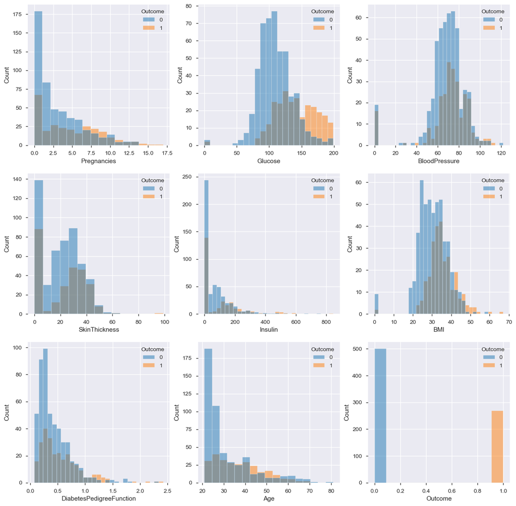

```python
EDA(df)
```

## Pandas Profiling

```python
profile =  ProfileReport(df, title = "Diabetes Report")
profile.to_widgets()
```

```
Tab(children=(HTML(value='<div id="overview-content" class="row variable spacing">\n    <div class="row">\n   …
```

Report generated with pandas-profiling.

# Data Preprocessing

```python
COLS = df.columns.drop('Outcome')
df.head(), COLS
```

```
(   Pregnancies  Glucose  BloodPressure  SkinThickness  Insulin   BMI  \
 0            6      148             72             35        0  33.6
 1            1       85             66             29        0  26.6
 2            8      183             64              0        0  23.3
 3            1       89             66             23       94  28.1
 4            0      137             40             35      168  43.1

    DiabetesPedigreeFunction  Age  Outcome
 0                     0.627   50        1
 1                     0.351   31        0
 2                     0.672   32        1
 3                     0.167   21        0
 4                     2.288   33        1  ,
 Index(['Pregnancies', 'Glucose', 'BloodPressure', 'SkinThickness', 'Insulin',
        'BMI', 'DiabetesPedigreeFunction', 'Age'],
       dtype='object'))
```

```python
df.isnull().sum()
```

```
Pregnancies                 0
Glucose                     0
BloodPressure               0
SkinThickness               0
Insulin                     0
BMI                         0
DiabetesPedigreeFunction    0
Age                         0
Outcome                     0
dtype: int64
```

```python
df.isna().sum()
```

```
Pregnancies                 0
Glucose                     0
BloodPressure               0
SkinThickness               0
Insulin                     0
BMI                         0
DiabetesPedigreeFunction    0
Age                         0
Outcome                     0
dtype: int64
```

## Correlation HITMAP

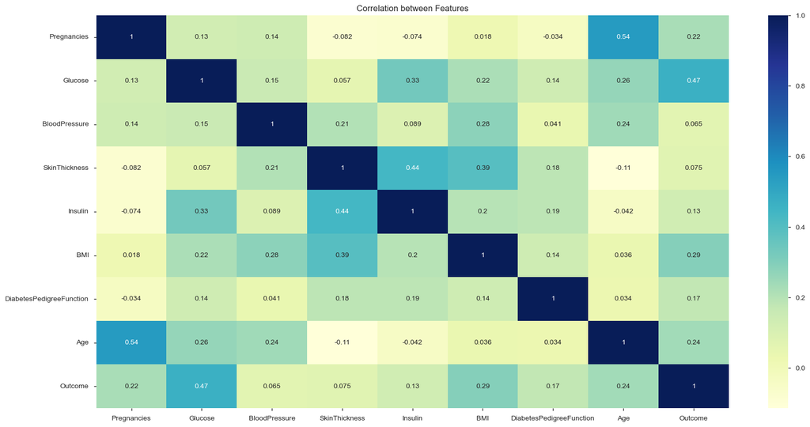

```python
plt.figure(figsize = (20,10))
sns.heatmap(df.corr(),annot=True , cmap ='YlGnBu' )

plt.title("Correlation between Features")
```

## Missing Values

```python
zero_null_fields = ['Glucose', 'BloodPressure', 'SkinThickness', 'Insulin', 'BMI']
df[zero_null_fields] = df[['Glucose', 'BloodPressure', 'SkinThickness', 'Insulin', 'BMI']].replace(0, np.NaN)

df.isna().sum()
```

```
Pregnancies                   0
Glucose                       5
BloodPressure                35
SkinThickness               227
Insulin                     374
BMI                          11
DiabetesPedigreeFunction      0
Age                           0
Outcome                       0
dtype: int64
```

```python
def handle_missing(data, column:str):
    data.loc[(data['Outcome'] == 0 ) & (data[column].isnull()), column] = df.groupby('Outcome')[column].median()[0]
    data.loc[(data['Outcome'] == 1 ) & (data[column].isnull()), column] = df.groupby('Outcome')[column].median()[1]

    return data

cols = ['Glucose', 'BloodPressure', 'SkinThickness', 'BMI', 'Insulin']

for col in cols:
    handle_missing(df, col)

df.isna().sum()
```

```
Pregnancies                 0
Glucose                     0
BloodPressure               0
SkinThickness               0
Insulin                     0
BMI                         0
DiabetesPedigreeFunction    0
Age                         0
Outcome                     0
dtype: int64
```

## Outliers

```python
def handle_outlier(df, col) :
    # IQR
    q1 = 0.25; q3 = 0.90

    Q1 = df[col].quantile(q1)
    Q3 = df[col].quantile(q3)
    iqr = Q3 - Q1

    up_b = Q3 + 1.5 * iqr
    low_b = Q1 - 1.5 * iqr

    df.loc[(df[col] < low_b), col] = low_b
    df.loc[(df[col] > up_b), col] = up_b
```

```python
for col in df.columns :
    handle_outlier(df, col)
```

## Scaling Data

```python
rs = RobustScaler()
df[COLS] = rs.fit_transform(df[COLS])
```

## Drop Insulin (Bad :/)

```python
#df = df.drop(['Insulin'], axis = 1)
#df
```

## Pandas Profiling (after Preprocessing)

```python
profile =  ProfileReport(df, title = "Diabetes Report")
profile.to_widgets()
```

```
Tab(children=(HTML(value='<div id="overview-content" class="row variable spacing">\n    <div class="row">\n   …
```

Report generated with pandas-profiling.

# Machine Learning

## Train-Test Split

```python
x = df.drop(['Outcome'], axis=1)
y = df['Outcome']
```

```python
x_train, x_test, y_train, y_test = train_test_split(x, y, test_size = 0.2, random_state = 42, stratify = y, shuffle = True)
```

## Balancing

```python
oversample = SMOTE(random_state = 42, k_neighbors = 10)

x_smote, y_smote = oversample.fit_resample(x_train, y_train)
x_train, y_train = x_smote, y_smote
```

```python
y_smote.value_counts()
```

```
0.0    400
1.0    400
Name: Outcome, dtype: int64
```

### Classifiers

```python
# models
classifiers = [
    DecisionTreeClassifier(max_depth = 3, random_state = 42),
    AdaBoostClassifier(DecisionTreeClassifier(random_state = 42)),
    RandomForestClassifier(max_depth = 5, random_state = 42),
    GradientBoostingClassifier(random_state = 42),
    LogisticRegression(random_state = 42, solver='lbfgs', max_iter=10000),
    SVC(random_state = 42, probability = True),
    KNeighborsClassifier(n_neighbors = 5, algorithm = "kd_tree"),
    GaussianNB(),
    MLPClassifier(solver = 'lbfgs', alpha = 1e-5, hidden_layer_sizes=(5, 2), random_state = 1),
    BaggingClassifier(SVC(random_state = 42, probability = True), max_samples = 0.5, max_features = 0.7),
    ExtraTreesClassifier(n_estimators = 10, max_depth = None, min_samples_split = 2, random_state = 0),
    XGBClassifier(learning_rate= 0.01,max_depth = 3,n_estimators = 1000)
]
```

```python
def make_classification(classifiers, x_train, x_test, y_train, y_test) :

    # metrics
    acc, f1, AUC, recall, cross_val, prec = [ ], [ ], [ ], [ ], [ ], [ ]
    models = [ ]

    for classifier in classifiers :
        clf = classifier
        clf.fit(x_train, y_train)

        y_pred = clf.predict(x_test)
        y_prob = clf.predict_proba(x_test)

        acc.append(((accuracy_score(y_test,y_pred))) * 100)
        cross_val.append(sum(cross_val_score(clf, x_train, y_train, cv = 10, scoring = "accuracy"))/10)
        f1.append(((f1_score(y_test,y_pred))) * 100)
        AUC.append(((roc_auc_score(y_test,y_prob[:, 1]))) * 100)
        recall.append(((recall_score(y_test,y_pred))) * 100)
        prec.append(((precision_score(y_test,y_pred))) * 100)
        models.append(clf.__class__.__name__)

    res = pd.DataFrame({
        "Accuracy" : acc,
        "Cross Val" : cross_val,
        "F1" : f1,
        "ROC" : AUC,
        "Recall" : recall,
        "Precision" : prec,
        "ML Models" : models,
    })

    res = (res.sort_values(by = ['ROC','F1'], ascending = False).reset_index(drop =  True))
    return res
```

```python
res = make_classification(classifiers, x_train, x_test, y_train, y_test)
res
```

[output not shown]

[output not shown]

### Ensemble

```python
gb_clf = GradientBoostingClassifier(random_state = 42)
rf_clf = RandomForestClassifier(max_depth = 5, random_state = 42)
nn_clf = MLPClassifier(solver = 'lbfgs', alpha = 1e-5, hidden_layer_sizes=(5, 2), random_state = 1)
svm_clf = SVC(random_state = 42, probability = True)
svm_bg_clf = BaggingClassifier(SVC(random_state = 42, probability = True), max_samples = 0.5, max_features = 0.7)
xgb_clf = XGBClassifier(learning_rate= 0.01,max_depth = 3, n_estimators = 1000)
```

```python
voting_clf = VotingClassifier(
 estimators = [('gb', gb_clf), ('rf', rf_clf), ('svm_bagging', svm_bg_clf)],
 voting = 'soft')

voting_clf.fit(x_train, y_train)
```

```
VotingClassifier(estimators=[('gb',
                              GradientBoostingClassifier(random_state=42)),
                             ('rf',
                              RandomForestClassifier(max_depth=5,
                                                     random_state=42)),
                             ('svm_bagging',
                              BaggingClassifier(base_estimator=SVC(probability=True,
                                                                   random_state=42),
                                                max_features=0.7,
                                                max_samples=0.5))],
                 voting='soft')
```

```python
y_pred = voting_clf.predict(x_test)
y_prob = voting_clf.predict_proba(x_test)
```

```python
pd.Series({"Acc :" : accuracy_score(y_test, y_pred) * 100,"F1 : " : f1_score(y_test, y_pred) * 100,"AUC : " : roc_auc_score(y_test,y_prob[:, 1]) * 100,"Recall : " : ((recall_score(y_test,y_pred))) * 100})
```

```
Acc :        87.662338
F1 :         83.478261
AUC :        95.481481
Recall :     88.888889
dtype: float64
```

## Cross Validation

```python
def cross_val(classifiers, x_train, y_train) :
    cv_train, cv_test, diff, models =  [], [], [], []

    for classifier in classifiers :
        clf = classifier
        #clf.fit(x_train, y_train)

        cv = cross_validate(clf, x_train, y_train, cv = 5, scoring = "accuracy", return_train_score = True)

        cv_train.append(cv['train_score'].mean() * 100)
        cv_test.append(cv['test_score'].mean() * 100)
        diff.append((cv['train_score'].mean() - cv['test_score'].mean()) * 100)
        models.append(clf.__class__.__name__)


    res = pd.DataFrame({
        "CV Train" : cv_train,
        "CV Test" : cv_test,
        "Diff" : diff,
        "ML Model" : models
    })

    res = (res.sort_values(by = ['CV Test', 'CV Train'], ascending = False).reset_index(drop =  True))

    return res
```

```python
nclf = classifiers
nclf.pop(8)
```

```
MLPClassifier(alpha=1e-05, hidden_layer_sizes=(5, 2), random_state=1,
              solver='lbfgs')
```

```python
nclf.append(
    VotingClassifier(
 estimators = [('gb', gb_clf), ('rf', rf_clf), ('svm_bagging', svm_bg_clf)],
 voting = 'soft')
)
```

```python
nclf
```

```
[DecisionTreeClassifier(max_depth=3, random_state=42),
 AdaBoostClassifier(base_estimator=DecisionTreeClassifier(random_state=42)),
 RandomForestClassifier(max_depth=5, random_state=42),
 GradientBoostingClassifier(random_state=42),
 LogisticRegression(max_iter=10000, random_state=42),
 SVC(probability=True, random_state=42),
 KNeighborsClassifier(algorithm='kd_tree'),
 GaussianNB(),
 BaggingClassifier(base_estimator=SVC(probability=True, random_state=42),
                   max_features=0.7, max_samples=0.5),
 ExtraTreesClassifier(n_estimators=10, random_state=0),
 XGBClassifier(base_score=0.5, booster='gbtree', colsample_bylevel=1,
               colsample_bynode=1, colsample_bytree=1, enable_categorical=False,
               gamma=0, gpu_id=-1, importance_type=None,
               interaction_constraints='', learning_rate=0.01, max_delta_step=0,
               max_depth=3, min_child_weight=1, missing=nan,
               monotone_constraints='()', n_estimators=1000, n_jobs=8,
               num_parallel_tree=1, predictor='auto', random_state=0,
               reg_alpha=0, reg_lambda=1, scale_pos_weight=1, subsample=1,
               tree_method='exact', validate_parameters=1, verbosity=None),
 VotingClassifier(estimators=[('gb',
                               GradientBoostingClassifier(random_state=42)),
                              ('rf',
                               RandomForestClassifier(max_depth=5,
                                                      random_state=42)),
                              ('svm_bagging',
                               BaggingClassifier(base_estimator=SVC(probability=True,
                                                                    random_state=42),
                                                 max_features=0.7,
                                                 max_samples=0.5))],
                  voting='soft')]
```

```python
cv_res = cross_val(nclf, x_train, y_train)
cv_res
```

[output not shown]

|  | CV Train | CV Test | Diff | ML Model |
| --- | --- | --- | --- | --- |
| 0 | 94.09375 | 88.500 | 5.59375 | VotingClassifier |
| 1 | 97.59375 | 88.375 | 9.21875 | XGBClassifier |
| 2 | 100.00000 | 88.250 | 11.75000 | ExtraTreesClassifier |
| 3 | 99.00000 | 88.250 | 10.75000 | GradientBoostingClassifier |
| 4 | 92.43750 | 87.250 | 5.18750 | RandomForestClassifier |
| 5 | 90.12500 | 86.875 | 3.25000 | SVC |
| 6 | 88.15625 | 85.875 | 2.28125 | BaggingClassifier |
| 7 | 88.15625 | 85.625 | 2.53125 | DecisionTreeClassifier |
| 8 | 100.00000 | 85.500 | 14.50000 | AdaBoostClassifier |
| 9 | 89.81250 | 85.375 | 4.43750 | KNeighborsClassifier |
| 10 | 80.78125 | 80.125 | 0.65625 | LogisticRegression |
| 11 | 78.96875 | 78.625 | 0.34375 | GaussianNB |

## Fine Tuning

### 1) GradientBoostingClassifier

```python
gb_clf = GradientBoostingClassifier(
    random_state = 42,
    min_samples_split = 100,
    min_samples_leaf = 20,
    max_depth = 2,
    max_features = 3,
    learning_rate = 0.05,
    subsample = 0.65,
)
```

```python
cross_val([gb_clf], x_train, y_train)
```

|  | CV Train | CV Test | Diff | ML Model |
| --- | --- | --- | --- | --- |
| 0 | 90.09375 | 87.25 | 2.84375 | GradientBoostingClassifier |

### 2) ExtraTreesClassifier

```python
ex_clf = ExtraTreesClassifier(
    random_state = 42,
    max_depth = 6,
    min_samples_split = 20,
    max_features = "log2",
)
```

```python
cross_val([ex_clf], x_train, y_train)
```

|  | CV Train | CV Test | Diff | ML Model |
| --- | --- | --- | --- | --- |
| 0 | 89.59375 | 86.875 | 2.71875 | ExtraTreesClassifier |

### 3) SVC

```python
svm_clf = SVC(
    random_state = 42,
    probability = True,
    C = 1,
    kernel = "rbf",
    gamma = "scale",
)
```

```python
cross_val([svm_clf], x_train, y_train)
```

|  | CV Train | CV Test | Diff | ML Model |
| --- | --- | --- | --- | --- |
| 0 | 90.125 | 86.875 | 3.25 | SVC |

### 4) Ensemble

```python
voting_clf = VotingClassifier(
    estimators = [('gb', gb_clf), ('ex', ex_clf), ('svm', svm_clf)],
    voting = 'soft'
)
```

```python
cross_val([voting_clf], x_train, y_train)
```

|  | CV Train | CV Test | Diff | ML Model |
| --- | --- | --- | --- | --- |
| 0 | 90.15625 | 87.75 | 2.40625 | VotingClassifier |

```python
make_classification([ex_clf, svm_clf, gb_clf, voting_clf], x_train, x_test, y_train, y_test)
```

[output not shown]

```python
y_pred_vt = voting_clf.predict(x_test)
y_pred_gb = gb_clf.predict(x_test)
```

```python
accuracy_score(y_test, y_pred_vt) * 100, accuracy_score(y_test, y_pred_gb) * 100,
```

```
(86.36363636363636, 87.66233766233766)
```

```python
cross_val([voting_clf, gb_clf], x_train, y_train)
```

|  | CV Train | CV Test | Diff | ML Model |
| --- | --- | --- | --- | --- |
| 0 | 90.15625 | 87.75 | 2.40625 | VotingClassifier |
| 1 | 90.09375 | 87.25 | 2.84375 | GradientBoostingClassifier |

```python
cross_val([voting_clf, gb_clf], x, y)
```

|  | CV Train | CV Test | Diff | ML Model |
| --- | --- | --- | --- | --- |
| 0 | 91.211038 | 88.806553 | 2.404485 | GradientBoostingClassifier |
| 1 | 91.374169 | 87.372889 | 4.001281 | VotingClassifier |

# Using PCA (Just a Showcase)

#### in this problem due to low number of demensions we do not need Demensionality Reduction Methods and Using PCA here is just for educational purposes

```python
from sklearn.decomposition import PCA
```

```python
pca = PCA()
pca.fit(x_train)

cumsum = np.cumsum(pca.explained_variance_ratio_)
d = np.argmax(cumsum >= 0.95) + 1
```

```python
d
```

```
7
```

```python
pca = PCA(n_components = 0.90)
x_redu = pca.fit_transform(x_train)
```

```python
pca_gb_clf = GradientBoostingClassifier(
    random_state = 42,
    min_samples_split = 100,
    min_samples_leaf = 20,
    max_depth = 2,
    max_features = 3,
    learning_rate = 0.05,
    subsample = 0.65,
)
```

```python
cross_val([pca_gb_clf], x_redu, y_train)
```

|  | CV Train | CV Test | Diff | ML Model |
| --- | --- | --- | --- | --- |
| 0 | 85.0 | 82.25 | 2.75 | GradientBoostingClassifier |

# BEST MODEL

### as we saw in the previous parts of this notebook we had out 2 best models as "Ensemble" and "GradientBoosting" now its time to compare them in different metrics and declare a winner

# Results

```python
make_classification([gb_clf, voting_clf], x_train, x_test, y_train, y_test)
```

|  | Accuracy | Cross Val | F1 | ROC | Recall | Precision | ML Models |
| --- | --- | --- | --- | --- | --- | --- | --- |
| 0 | 87.662338 | 0.87375 | 83.185841 | 94.555556 | 87.037037 | 79.661017 | GradientBoostingClassifier |
| 1 | 86.363636 | 0.87750 | 82.051282 | 93.592593 | 88.888889 | 76.190476 | VotingClassifier |

## 1) Accuracy

not the most important metric in this problem

as we can see the **GB Classifier** is slightly doing better

## 2) Precision

both have rather low precision but once again **GB Classifer** is doing better even much better ! **considering the 3.5% difference**

## 3) Recall

in my eyes in this particular problem recall can be one of the most if not the most important metric

the reasoning behind this idea is that it is really important to correctly detect the ones that have diabetes cause if not, they wont be diagnosed and as a result they will not be cured which may have some detrimental consequences

## 4) F1

well this one is obviously a win for **GB Classifier**

## 5) AUC

roc curve is also a really useful metric for this problem and one way to measure it is using **AUC (Area Under Curve)**

as we already had figured it out, **GB Classifier** has the upper hand

### Overfitting / Underfitting

none of these two has underfitting by any means

as for overfitting based of what we saw in the previous parts of this notebook we can say that none of these has overfitting problem as well however the diffrence between train/test in **GB Classifier** is somewhat smaller which makes it a slightly more stable model

# Conclusion

based on all models and parameter tuning that we did we can safely say that **"Gradient Boosting Classifer"** is our best model

```python
make_classification([gb_clf], x_train, x_test, y_train, y_test)
```

|  | Accuracy | Cross Val | F1 | ROC | Recall | Precision | ML Models |
| --- | --- | --- | --- | --- | --- | --- | --- |
| 0 | 87.662338 | 0.87375 | 83.185841 | 94.555556 | 87.037037 | 79.661017 | GradientBoostingClassifier |

```python
cross_val([gb_clf], x, y)
```

|  | CV Train | CV Test | Diff | ML Model |
| --- | --- | --- | --- | --- |
| 0 | 91.211038 | 88.806553 | 2.404485 | GradientBoostingClassifier |

```python
y_scores = cross_val_predict(gb_clf, x, y, cv = 3, method = "decision_function")
```

```python
precisions, recalls, thresholds = precision_recall_curve(y, y_scores)
```

```python
def plot_precision_recall_vs_threshold(precisions, recalls, thresholds) :
    plt.plot(thresholds, precisions[:-1], "b--", label = "Precision")
    plt.plot(thresholds, recalls[:-1], "g-", label = "Recall")
```

# Precision-Recall Curve

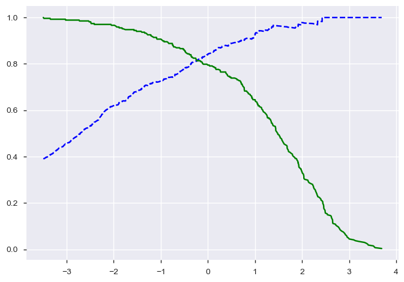

```python
plot_precision_recall_vs_threshold(precisions, recalls, thresholds)
plt.show()
```

```python
fpr, tpr, thresholds = roc_curve(y, y_scores)
```

```python
def plot_roc_curve(fpr, tpr, label = None) :
    plt.plot(fpr, tpr, linewidth = 2,label = label)
    plt.plot([0, 1], [0, 1], 'k--')
```

# ROC Curve

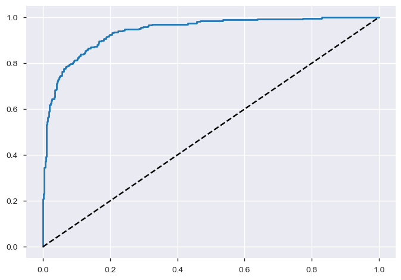

```python
plot_roc_curve(fpr, tpr, "ROC Curve")
plt.show()
```

```python
roc_auc_score(y, y_scores)
```

```
0.9415447761194029
```